# Introduction to R

UCLA OARC Statistical Methods and Data Analytics

# Background

# Purpose of this seminar

This seminar introduces the funtionality of `R`, with a focus on data analysis.

In this seminar we will learn:

- how to interact with `R` through `RStudio`
- a bit of `R` coding
- tools to import, clean, manage, and export data
- simple data analysis functions
- the basics of two `R` graphical systems
- how to use `R` to share your data analysis with others

> Coding instructions to help you learn `R` will appear in boxes like this.

# `R` as a programming environment

`R` is a programming environment for statistical computing and graphics.

`R`

- serves as a data analysis and storage facility
- is designed to perform operations on vectors and matrices
- uses a well-developed but simple programming language
- allows for rapid development of new tools according to user demand

These tools are distributed as packages, which any user can download to customize the `R` environment.

# Why (and why not) `R`?

`R` has many advantages as data analysis software:

- Free
- [Free online books to learn R](https://bookdown.org/)
  - online community is much larger than those for other statistical software
- [Powerful, intuitive graphics systems](https://ggplot2.tidyverse.org/) make it easy to produce publication-quality graphics
- Easily create data analysis reports as documents and presentations for reproducibility with [R Markdown](https://rmarkdown.rstudio.com/)
- Because it is a true programming language, `R` makes it much easier to add functionality and flexibility as needed compared to other data analysis software
- Many specialized packages featuring analysis tools not available in other software

`R` also has a few disadvantages:

- somewhat more difficult to master than other statistical software
- frequent updates require maintenance

# RStudio

# RStudio

You can work directly in `R`, but most users prefer a graphical interface. We *highly* recommend using [RStudio](http://www.rstudio.com/ide/), an integrated development environment (IDE) that features:

- a console
- a powerful code/script editor featuring
- special tools for plotting, viewing R objects and code history
- cheatsheets for R programming
- tab-completion for object names and function arguments (enough reason by itself!)

# RStudio Console

You can input and execute commands directly in the console.

Output of commands will typically be displayed in the console.

The `RStudio` console features tab-code-completion and live help for function coding.

> Type `rno` into the `RStudio` console, wait a second, and when a window with `rnorm` appears, hit the **Tab** key.

Once you have the `rnorm()` function name completed, if the cursor is inside of `()`, `RStudio` will remind you of the the function’s arguments in a window . You can also hit the `Tab` key to see and issue the function argument names.

> Place the cursor inside of `rnorm()`. Hit the **Tab** key twice, and then type the number `10`. Hit **Enter** to execute the code.

You have just drawn 10 random numbers from a normal distribution.

# RStudio Script Editor

Most `R` programs written for data analysis consist of many commands, making entering code line-by-line into the console inefficient.

Instead, we use the script editor to save our commands as a record of the steps we took to analyze our data. We can also issue `R` commands directly from the editor.

The script editor features the same tab-code-completion and function help as the console, as well as syntax highlighting.

> If you do not see the script editor already open, open it now by selecting `File` > `New File` > `R Script`.

> Write the code `1 + 2` in the script editor.  
> On the next line, type the code `log`. When the tab-completion window appears with a list of possible commands, hit **Tab** to choose `log()`. Enter 10 inside the `()`.

To execute code directly from the script editor, place the cursor inside the command (or highlight the entire command), and then hit `Ctrl-Enter` (on PCs, use `Command-Enter` on Macs). This will advance the cursor to the next command, where you can hit Ctrl-Enter again to run it, advancing the cursor to the next command…

> Execute the two commands in the script editor using the keyboard shortcuts.

Make sure to periodically save your scripts. Most R scripts are saved with the `.R` extension.

> Save your R script with the name `mycode.R`.

> Unless otherwise specified, all coding instructions for this seminar should be entered into the script editor.

# RStudio Environment pane

`R` stores both data and output from data analysis (as well as everything else) in *objects*.

Data are assigned to and stored in objects using the `<-` or `=` operator.

> In the script editor, type and run the code `x <- 5` to create our first object.

Once you create an object, it should appear in the `RStudio` `Environment` pane.

To print the contents of an object to the console, specify the object’s name alone.

> Specify and execute the code `x` to view the contents of `x` in the console.

# Help for `R` and `RStudio`

The `RStudio` `Help` menu contains links to many documents for help with both `R` (select `R Help`) and `RStudio` (see `RStudio Docs` and `RStduio Community Forum`).

We particularly like the `Cheatsheets`, which are compact documents crammed with useful information on how to use various products made by the `RStudio` group.

> Open the cheatsheet for `RStudio` by selecting the `Help` menu -> `Cheat Sheets` -> `RStudio IDE Cheat Sheet`. Note the cheatsheet will usually be downloaded in a web browser as a .pdf.

# Working with `R` packages

# Base `R` and packages

Base `R` and most `R` packages are available for download from the Comprehensive R Archive Network (CRAN)

- [cran.r-project.org](http://cran.r-project.org/)
- base `R` comes with a number of basic data management, analysis, and graphical tools
- However, `R`’s power and flexibility lie in its array of packages (currently more than 15,000 on CRAN!)

# Installing packages

To use packages in `R`, we must first install them using the `install.packages()` function, which typically downloads the package from CRAN and installs it for use.

Use the argument `dependencies=TRUE` to load all other packages required by the targeted package.

```r
# uncomment (remove ##) to run
install.packages("dplyr", dependencies=TRUE)
install.packages("ggplot2", dependencies=TRUE)
install.packages("rmarkdown", dependencies=TRUE)
```

> If you have not installed them already, please install `dplyr`, `ggplot2`, and `rmarkdown` with the necessary dependencies.

# Loading packages

After installing a package, we can load it into the R environment using the `library()` or `require()` functions, which more or less do the same thing.

Functions and data structures within the package will then be available for use.

```r
library(dplyr)
library(ggplot2)
```

> Load the package `dplyr` into your session now with `library()`.

# Vignettes *

Many packages include vignettes – longer, tutorial style guides for a package.

To see a list of available vignettes for the packages that are loaded, use `vignette()` with no arguments. Then to view a vignette, place its name inside `vignette()`:

```r
# list all available vignettes
vignette()
```

> View the “Introduction to dplyr” vignette by issuing the command `vignette("dplyr")`.

# Basic R coding

# R programming 1: Coding

Remember that we assign data to objects with `<-` or `=`.

Character data (i.e. strings) are surrounded by `"` or `'`.

> In the script editor, create an object named `a` and assign it the character string “hello”.

Commands are separated either by a `;` or by a newline.

`R` is case sensitive.

The `#` character at the beginning of a line signifies a comment, which is not executed.

> On the next line, create an object named `b`, assign it the logarithm of 10 (using the `log()` function), but put a `#` at the beginning of the line. What happens when you try to execute this line?

Commands can extend beyond one line of text. Put operators like `+` at the end of lines for multi-line commands.

```r
# Put operators like + at the end of lines
2 +
  3
## [1] 5
```

# R programming 2: Functions and help files

Functions perform most of the work on data in `R`.

Functions in `R` are much the same as they are in math – they perform some operation on an input and return some output. For example, the mathematical function $f(x) = x^2$, takes an input $x$, and returns its square. Similarly, the `mean()` function in `R` takes a vector of numbers and returns its mean.

The inputs to functions are often referred to as *arguments*.

Help files for `R` functions are accessed by preceding the name of the function with `?`.

> Try opening the help file for `log()` with the code `?log`.

In the help file, we will find the following useful sections:

- **Description**: overview of the function
- **Usage**: syntax, with list of arguments in particular order
- **Arguments**: description of arguments
- **Details**: in depth description of function’s operation
- **Value**: output of the function
- **Examples**: copy-and-pasteable examples

# R programming 3: Function arguments

Values for arguments to functions can be specified either by name or position.

For `log()`, we see the first argument is `x`, the number whose log we want to take, and the second is `base`, the base of the logarithm.

```r
# specifying arguments by name
log(x=100, base=10)
## [1] 2

# specifying arguments by position
log(8, 2)
## [1] 3
```

In the help file `Usage` section, if something is specified after an argument’s name and `=`, it is the default value.

In the `log()` help file, we see that the default value for `base` is `exp(1)`, or $e$, making `log()` a natural logarithm function by default.

# Vectors

Vectors, the fundamental data structure in `R`, are one-dimensional and homogeneous.

A single variable can usually be represented by one of the following vector data types:

- logical: TRUE or FALSE (1 or 0)
- integer: integers only (represented by a number followed by L; e.g. 10L is the integer 10)
- double: real numbers, also known as *numeric*
- character: strings

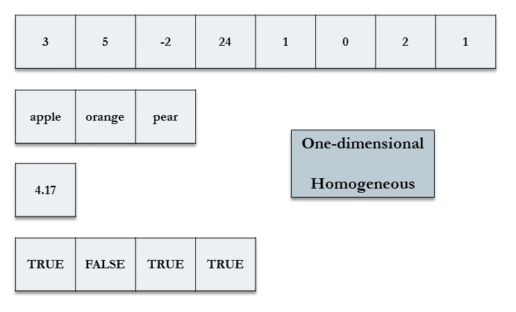

Fig 2.1. Integer, character, double, and logical vector

A single value is a vector of length one in `R`.

# Creating vectors

The `c()` function combines values of common type together to form a vector.

```r
# create a vector
first_vec <- c(1, 3, 5)
first_vec
## [1] 1 3 5

# length() returns the number of elements
char_vec <- c("these", "are", "some", "words")
length(char_vec)
## [1] 4

# the result of this comparison is a logical vector
first_vec > c(2, 2, 2)
## [1] FALSE  TRUE  TRUE
```

To create vectors with a predictable sequence of elements, use `rep()` for repeating elements and `seq()` for sequential elements.

The expression `m:n` will generate a vector of integers from `m` to `n`

```r
# first argument to rep is what to repeate
# the second argument is number of repetitions
rep(0, times=3)
## [1] 0 0 0
rep("abc", 4)
## [1] "abc" "abc" "abc" "abc"

# arguments for seq are from, to, by
seq(from=1, to=5, by=2)
## [1] 1 3 5
seq(10, 0, -5)
## [1] 10  5  0

# colon operator
3:7
## [1] 3 4 5 6 7

# you can nest functions
rep(seq(1,3,1), times=2)
## [1] 1 2 3 1 2 3
```

> Create the vector (4,5,6) in three different ways using `c()`, `seq()`, and the `:` operator.  
> Try creating the vector (2,2,1,1) in at least two different ways.

# Subsetting vectors with []

Elements of a vector can be accessed or subset by specifying a vector of numbers (of length 1 or greater) inside `[]`.

```r
# create a vector 10 to 1
# putting () around a command will cause the result to be printed
(a <- seq(10,1,-1))
##  [1] 10  9  8  7  6  5  4  3  2  1

# second element
a[2]
## [1] 9

# first 5 elements
a[seq(1,5)]
## [1] 10  9  8  7  6

# first, third, and fourth elements
a[c(1,3,4)]
## [1] 10  8  7
```

> Create the vector `y` as the integers counting down from 10 to 1. Extract the second, fifth, and seventh element of this vector `y`.

# Conditional selection - subsetting by value

Vectors elements can also be subset with a logical (TRUE/FALSE) vector, known as *logical subsetting*.

```r
scores <- c(55, 24, 43, 10)
scores[c(FALSE, TRUE, TRUE, FALSE)]
## [1] 24 43
```

This allows us to subset a vector by checking if a condition is satisifed:

```r
# this returns a logical vector...
scores < 30
## [1] FALSE  TRUE FALSE  TRUE

# ...that we can now use to subset
scores[scores<30]
## [1] 24 10
```

> Use conditional selection to find the numbers in `y` (integers from 10 to 1) that when multiplied by 2, the result is greater than 15.

# Importing and Exporting Data

# Dataset files

`R` works most easily with datasets stored as text files. Typically, values in text files are separated, or delimited, by tabs or spaces:

[output not shown]

or by commas (CSV file):

```
gender,id,race,ses,schtyp,prgtype,read,write,math,science,socst
0,70,4,1,1,general,57,52,41,47,57
1,121,4,2,1,vocati,68,59,53,63,61
0,86,4,3,1,general,44,33,54,58,31
0,141,4,3,1,vocati,63,44,47,53,56
```

# Reading in text data

R provides several related functions to read data stored as files.

Use `read.csv()` to read in data stored as CSV and `read.delim()` to read in text data delimited by other characters (such as tabs or spaces).

For `read.delim()`, specify the delimiter in the `sep=` argument.

Both `read.csv()` and `read.delim()` assume the first row of the text file is a row of variable names. If this is not true, use the argument `header=FALSE`.

Although we are retrieving files over the internet for this class, these functions are typically used for files saved to disk.

Note how we are assigning the loaded data to objects.

```r
# basic syntax of read.csv, not run
data <- read.csv("/path/to/file.csv")

# specification for tab-delimited file
dat.tab <- read.delim("/path/to/file.txt",  sep="\t")
```

> Create a dataset called `dat_csv` by loading a dataset from our server at this address: https://stats.oarc.ucla.edu/stat/data/hsbraw.csv .

```r
dat_csv <- read.csv("https://stats.oarc.ucla.edu/stat/data/hsbraw.csv")
```

# Exporting data

We can export our data to a .csv file with `write.csv()`.

If you need to save multiple objects from your session, you can save whatever objects you need with `save()`, which creates a binary `.Rdata` file, which can loaded for later use with `load()`.

We did not specify realistic path names below.

```r
# write a csv file
write.csv(dat_csv, file = "path/to/save/filename.csv")

# save these objects to an .Rdata file
save(dat_csv, mydata, file="path/to/save/filename.Rdata")
```

# Packages for importing

Packages to read and write data in other software formats:

- `readxl` : Excel files
- `haven`: Stata, SAS, and SPSS

# Data Frames

# Data frames

Data sets for statistical analysis are typically stored in *data frames* in `R`. The objects created by `read.csv()` and `read.table()` are data frames.

Data frames are rectangular, where the columns are variables and the rows are observations of those variables.

Data frame columns can be of different data types (some double, some character, etc.) – but they must be equal length

Real datasets usually combine variables of different types, so data frames are well suited for storage.

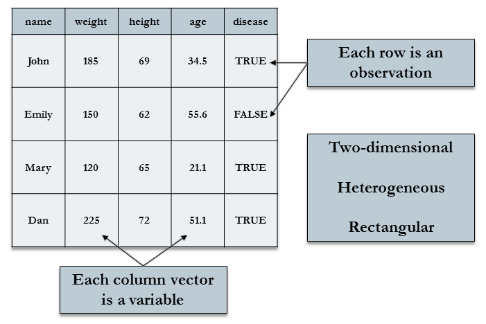

Fig 2.5. Data frame with 4 observations of 5 variables

# Viewing data as a spreadsheet with `View()`, `head()` and `tail()`

Use `View()` on a dataset to open a spreadsheet-style view of a dataset. In RStuido, clicking on a dataset in the **Environment** pane will `View()` it.

```r
View(dat_csv)
```

> View the dataset `dat_csv`.

For large data files, use `head()` and `tail()` to look at a specified number of rows at the begininning or end of a dataset, respectively.

```r
# first 2 rows
head(dat_csv, 2)
##    id female    ses schtyp     prog read write math science socst       honors
## 1  45 female    low public vocation   34    35   41      29    26 not enrolled
## 2 108   male middle public  general   34    33   41      36    36 not enrolled
##   awards cid
## 1      0   1
## 2      0   1
```

```r
# last 8 rows
tail(dat_csv, 8)
##      id female    ses  schtyp     prog read write math science socst
## 193 174   male middle private academic   68    59   71      66    56
## 194  95   male   high  public academic   73    60   71      61    71
## 195  61 female   high  public academic   76    63   60     -99   -99
## 196 100 female   high  public academic   63    65   71      69    71
## 197 143   male middle  public vocation   63    63   75      72    66
## 198  68   male middle  public academic   73    67   71      63    66
## 199  57 female middle  public academic   71    65   72      66    56
## 200 132   male middle  public academic   73    62   73      69    66
##           honors awards cid
## 193 not enrolled      2  20
## 194     enrolled      2  20
## 195     enrolled      4  20
## 196                 -99  20
## 197     enrolled      4  20
## 198     enrolled      7  20
## 199     enrolled      5  20
## 200     enrolled      3  20
```

# Subsetting data frames

With a two-dimensional structure, data frames can be subset with matrix notation `[rows, columns]`.

Use vectors to subset multiple rows/columns.

Omitting `rows` or `columns` specifies all rows and columns, respectively.

```r
# use data.frame() to create a data frame manually
mydata <- data.frame(patient=c("Smith", "Jones", "Williams"),
                     height=c(72, 61, 66),
                     diabetic=c(1, 0, 0))


# row 3 column 2
mydata[3,2]
## [1] 66

# first two rows of column height
mydata[1:2, "height"]
## [1] 72 61

# all rows of columns patient and diabetic
mydata[,c("patient", "diabetic")]
##    patient diabetic
## 1    Smith        1
## 2    Jones        0
## 3 Williams        0
```

> Extract the 2nd, 5th, and 10th rows of the variable `math` in the `dat_csv` data set.

Variables, or columns, of a data frame can be selected with the `$` operator, and the resulting object is a vector.

We can further subset elements of the selected column vector using `[]`.

```r
# subsetting creates a numeric vector
mydata$height
## [1] 72 61 66

# just the second and third elements
mydata$height[2:3]
## [1] 61 66
```

> Extract the 2nd, 5th, and 10th rows of the variable `math` in the `dat_csv` data set using the `$` operator

# Naming data frame columns

`colnames(data_frame)` returns the column names of *data_frame* (or matrix).

`colnames(data_frame) <- c("some", "names")` assigns column names to *data_frame*.

```r
# get column names
colnames(mydata)
## [1] "patient"  "height"   "diabetic"

# assign column names (capitalizing them)
colnames(mydata) <- c("Patient", "Height", "Diabetic")
colnames(mydata)
## [1] "Patient"  "Height"   "Diabetic"

# to change one variable name, just use vector indexing
colnames(mydata)[3] <- "Diabetes"
colnames(mydata)
## [1] "Patient"  "Height"   "Diabetes"
```

# Examining the structure of an object

Use `dim()` on two-dimensional objects to get the number of rows and columns.

Use `str()`, to see the structure of the object, including its *class* and the data types of elements. We also see the first few rows of each variable.

```r
# number of rows and columns
dim(mydata)
## [1] 3 3

#d is of class "data.frame"
#all of its variables are of type "integer"
str(mydata)
## 'data.frame':    3 obs. of  3 variables:
##  $ Patient : chr  "Smith" "Jones" "Williams"
##  $ Height  : num  72 61 66
##  $ Diabetes: num  1 0 0
```

> Examine the structure of `dat_csv` with `str()`.

# Adding new variables to the data frame

You can add variables to data frames by declaring them to be column variables of the data frame as they are created.

Trying to add a column of the wrong length will result in an error.

```r
# this will add a column variable called logwrite to d
mydata$logHeight <- log(mydata$Height)

# now we see logwrite as a column in d
colnames(mydata)
## [1] "Patient"   "Height"    "Diabetes"  "logHeight"

# d has 200 rows, and the rep vector has 300
mydata$z <- rep(0, 5)
## Error in `$<-.data.frame`(`*tmp*`, z, value = c(0, 0, 0, 0, 0)): replacement has 5 rows, data has 3
```

Here are some useful functions to create variables from existing variables:

- `log()`: logarithm
- `min_rank()`: rank values
- `cut()`: cut a continuous variable into intervals with new integer value signifying into which interval original value falls
- `scale()`: standardizes variable (substracts mean and divides by standard deviation)
- `lag()`, `lead()`: lag and lead a variable
- `cumsum()`: cumulative sum
- `rowMeans()`, `rowSums()`: means and sums of several columns

> Add a variable to `dat_csv` called `cmath` that is the mean-centered math variable. To create this variable, subtract the mean of the `math` variable from the `math` variable itself.

> Add a variable to `dat_csv` called `zmath` that is the standardized math variable. To create this variable, divide (using `/`) the `cmath` variable by its standard deviation, using th`sd()` function.

> Add a variable to `dat_csv` called `zmath2` that is also the standardized math variable by using the `scale()` function on `dat_csv$math`.

> Use `head()` on `dat_csv` to examine the first few rows of the variables you just created.

# Data Management

# Preparing data for analysis

Taking the time to prepare your data before analysis can save you frustration and time spent cleaning up errors:

- Cut the data set down to only those observations (rows) and variables (columns) needed for analysis
- Combining data sets
- Make sure variable values are free of errors, such as impossible values or numeric codes for missing values

The package `dplyr` contains several easy-to-use data management functions that we will learn to use to manage our data.

```r
# load packages for this section
library(dplyr)
```

> If you have not already, load `dplyr` into the current session with `library()`.

# Subsetting rows of a data frame with `filter()`

The `dplyr` function `filter()` will subset the rows (observations) of a data frame according to some condition (e.g. all rows where a column value is greater than *x*, all rows where a column value is equal to *y*).

```r
# creating some data manually
dog_data <- data.frame(id = c("Duke", "Lucy", "Buddy", "Daisy", "Bear", "Stella"),
                       weight = c(25, 12, 58, 67, 33, 9),
                       sex=c("M", "F", "M", "F", "M", "F"),
                       location=c("north", "west", "north", "south", "west", "west"))



# dogs weighing more than 40
filter(dog_data, weight > 40)
##      id weight sex location
## 1 Buddy     58   M    north
## 2 Daisy     67   F    south

# female dogs in the north or south locations
filter(dog_data, (location == "north" | location == "south") & sex == "F")
##      id weight sex location
## 1 Daisy     67   F    south
```

> Create a data set from `dat_csv` called `low_read` that contains observations where the `read` score is less than or equal to 50.

> Create a data set from `dat_csv` called `mid_read` that contains observations where the `read` score is greater than 50 but also less than or equal to 60.

# Subsetting Variables (columns)

Often, datasets come with many more variable than we want. We can use the `dplyr` function `select()` to keep only the variables we need.

```r
# select 2 variables
select(dog_data, id, sex)
##       id sex
## 1   Duke   M
## 2   Lucy   F
## 3  Buddy   M
## 4  Daisy   F
## 5   Bear   M
## 6 Stella   F
```

Use `-` to unselect (select out) columns.

```r
# select everything BUT id and sex
select(dog_data, -c(id, sex))
##   weight location
## 1     25    north
## 2     12     west
## 3     58    north
## 4     67    south
## 5     33     west
## 6      9     west
```

# Appending observations (appending by rows)

Sometimes we are given our dataset in parts, with observations spread over many files (collected by different researchers, for example). To create one dataset, we need to append the datasets together row-wise.

The function `rbind()` appends data frames together. The variables must be the same between datasets.

Here, we `rbind()` a new data set of dogs, `more_dogs`, to our current `dog_data`.

```r
# make a data.frame of new dogs
more_dogs <- data.frame(id = c("Jack", "Luna"),
                        weight=c(38, -99),
                        sex=c("M", "F"),
                        location=c("east", "east"))


# make sure that data frames have the same columns
names(dog_data)
## [1] "id"       "weight"   "sex"      "location"
names(more_dogs)
## [1] "id"       "weight"   "sex"      "location"

# appended dataset combines rows
all_dogs <- rbind(dog_data, more_dogs)
all_dogs
##       id weight sex location
## 1   Duke     25   M    north
## 2   Lucy     12   F     west
## 3  Buddy     58   M    north
## 4  Daisy     67   F    south
## 5   Bear     33   M     west
## 6 Stella      9   F     west
## 7   Jack     38   M     east
## 8   Luna    -99   F     east
```

> Append `low_read` and `mid_read` and call the resulting data set `low_and_mid_read`. Check in the `Environment` pane that `low_and_mid_read` has the correct number of observations.

# Adding data columns by merging on a key variable *

We often receive separate datasets with different variables (columns) that must be *merged* on a key variable.

Merging is an involved topic, with many different kinds of merges possible, depending on whether every observation in one dataset can be matched to an observation in the other dataset. Sometimes, you’ll want to keep observations in one dataset, even if it is not matched. Other times, you will not.

We will solely demonstrate merges where only matched observations are kept.

We will use the `dplyr` function `inner_join()` to perform the merge. The base `R` function `merge()` can be used for the same type of merge.

`inner_join()` will search both datasets for any variables with the same name, and will use those as matching variables. If you need to control which variables are used to match, use the `by=` argument.

```r
# new dog variable
# matching variables do not have to be sorted
dog_vax <- data.frame(id = c("Luna", "Duke", "Buddy", "Stella", "Daisy", "Lucy", "Jack", "Bear"),
                      vaccinated = c(TRUE, TRUE, TRUE, TRUE, TRUE, FALSE, FALSE, FALSE))

# id appears in both datasets, so will be used to match observations
dogs <- inner_join(all_dogs, dog_vax)
## Joining, by = "id"
dogs
##       id weight sex location vaccinated
## 1   Duke     25   M    north       TRUE
## 2   Lucy     12   F     west      FALSE
## 3  Buddy     58   M    north       TRUE
## 4  Daisy     67   F    south       TRUE
## 5   Bear     33   M     west      FALSE
## 6 Stella      9   F     west       TRUE
## 7   Jack     38   M     east      FALSE
## 8   Luna    -99   F     east       TRUE
```

# Missing values

Missing values in `R` are represented by the reserved symbol `NA` (cannot be used for variable names).

Blank fields in a text file will generally be converted to `NA` when loaded into `R`.

Often, datasets use codes, such as impossible numeric values (e.g. -99) to denote missing values.

We can convert missing data codes like -99 in variables to `NA` with conditional selection.

```r
# subset to science values equal to -99, and then change
#  them all to NA
dogs$weight[dogs$weight == -99] <- NA
dogs$weight
## [1] 25 12 58 67 33  9 38 NA
```

# Missing values are contagious

In `R`, `NA` means “undefined”, so most operations involving an `NA` value will result in `NA` (as the result is “undefined”):

```r
# a sum involving "undefined" is "undefined"
1 + 2 + NA
## [1] NA

# NA could be larger or smaller or equal to 2
c(1, 2, 3, NA) > 2
## [1] FALSE FALSE  TRUE    NA

# mean is undefined because of the presence of NA
dogs$weight
## [1] 25 12 58 67 33  9 38 NA
mean(dogs$weight)
## [1] NA
```

However, many functions allow the argument `na.rm` (or soemthing similar) to be set to `TRUE`, which will first remove any `NA` values from the operation before calculating the result:

```r
# NA values will be removed first
sum(c(1,2,NA), na.rm=TRUE)
## [1] 3

mean(dogs$weight, na.rm=TRUE)
## [1] 34.57143
```

You cannot check for equality to `NA` because means “undefined”. It will always result in `NA`.

Use `is.na()` instead.

```r
# one of the values is NA
x <- c(1, 2, NA)

# check for equality to NA using == is wrong
# RStudio may give you a warning about this (to use is.na() instead)
x == NA
## [1] NA NA NA

# this is correct
is.na(x)
## [1] FALSE FALSE  TRUE
```

> In `dat_csv`, the variable `science` contains -99 values to signify missing. How can you identify which rows have -99 values?  
> Convert all of these -99 values to `NA`.  
> Calculate the mean of `science` ignoring the missing values.

# Basic Data Analysis

# Descriptive statistics for continuous variables

Common numeric summaries for continuous variables are the mean, median, and variance, obtained with `mean()`, `median()`, and `var()` (`sd()` for standard deviation), respectively.

`summary()` on a numeric vector provides the min, max, mean, median, and first and third quartiles (interquartile range).

```r
# create a new bloodtest data set
bloodtest <- data.frame(id = 1:10,
                        gender = c("female", "male", "female", "female", "female", "male", "male", "female", "male", "female"),
                        hospital = c("CLH", "MH", "MH", "MH", "CLH", "MH", "MDH", "MDH", "CLH", "MH"),
                        doc_id = c(1, 1, 1, 2, 2, 2, 3, 3, 3, 3),
                        insured = c(0, 1, 1, 1, 0, 1, 1, 0, 1, 1),
                        age = c(23, 45, 37, 49, 51, 55, 56, 37, 26, 40),
                        test1  = c(47, 67, 41, 65, 60, 52, 68, 37, 44, 44),
                        test2 = c(46, 57, 47, 65, 62, 51 ,62 ,44 ,46, 61),
                        test3 = c(49, 73, 50, 64, 77, 57, 75, 55, 62, 55),
                        test4 = c(61, 61, 51, 71, 56, 57, 61, 46, 46, 46))


mean(bloodtest$age)
## [1] 41.9
median(bloodtest$age)
## [1] 42.5
var(bloodtest$age)
## [1] 130.5444

summary(bloodtest$test1)
##    Min. 1st Qu.  Median    Mean 3rd Qu.    Max.
##   37.00   44.00   49.50   52.50   63.75   68.00
```

# Correlations

Correlations provide quick assessments of whether two continuous variables are linearly related to one another.

The `cor()` function estimates correlations. If supplied with 2 vectors, `cor()` will estimate a single correlation. If supplied a data frame with several variables, `cor()` will estimate a correlation matrix.

```r
# just a single correlation
cor(bloodtest$test1, bloodtest$test2)
## [1] 0.7725677

# use dplyr select() to pull out just the test variables
scores <- select(bloodtest, test1, test2, test3, test4)
cor(scores)
##           test1     test2     test3     test4
## test1 1.0000000 0.7725677 0.8174523 0.7959618
## test2 0.7725677 1.0000000 0.6691743 0.5298743
## test3 0.8174523 0.6691743 1.0000000 0.3612138
## test4 0.7959618 0.5298743 0.3612138 1.0000000
```

> Create a correlation table of the `dat_csv` variables `read`, `write`, and `math`.

# Frequency tables

The statistics mean, median and variance cannot be calculated meaningfully for categorical variables (unless just 2 categories).

Instead, we often present frequency tables of the distribution of membership to each category.

Use `table()` to produce frequency tables.

Use `prop.table()` on the tables produced by `table()` (i.e. the output) to see the frequencies expressed as proportions.

Some of the categorical variables in this dataset are:

```r
# table() produces counts
table(bloodtest$gender)
##
## female   male
##      6      4
table(bloodtest$hospital)
##
## CLH MDH  MH
##   3   2   5

# for proportions, use output of table()
#   as input to prop.table()
prop.table(table(bloodtest$hospital))
##
## CLH MDH  MH
## 0.3 0.2 0.5
```

# Crosstabs

Two-way and multi-way frequency tables (crosstabs) are used to explore the relationships between categorical variables.

We can use `table()` and `prop.table()` again. Within `prob.table()`, use `margin=1` for row proportions and `margin=2` for column proportions. Omitting `margin=` will give proportions of the total.

```r
# this time saving the freq table to an object
my2way <- table(bloodtest$gender, bloodtest$hospital)

# counts in each crossing of prog and ses
my2way
##
##          CLH MDH MH
##   female   2   1  3
##   male     1   1  2

# row proportions,
#   proportion of prog that falls into ses
prop.table(my2way, margin=1)
##
##                CLH       MDH        MH
##   female 0.3333333 0.1666667 0.5000000
##   male   0.2500000 0.2500000 0.5000000

# columns proportions,
#   proportion of ses that falls into prog
prop.table(my2way, margin=2)
##
##                CLH       MDH        MH
##   female 0.6666667 0.5000000 0.6000000
##   male   0.3333333 0.5000000 0.4000000
```

> Determine the proportion of each socio-economic group (variable `ses`) within each school type (variable `schtyp`) in the `dat_csv` data set.

# Statistical analysis in `R`

The `stats` package, loaded with base `R`, provides a wide array of commonly used statistical tools, including:

- chi-square tests and several related/similar tests
- t-tests
- correlation and covariance
- ANOVA and linear regression models
- generalized linear regression models (logistic, poisson, etc.)
- time series analysis
- statistical distributions (random numbers, density, distribution, and quantile functions)

Even more tools are available in various downloadable packages.

We will be covering only tools available in `stats` in this seminar.

# Chi-square test of indepedence

Chi-square tests are often used to test for association between two categorical variables. It tests whether the proportions of membership to categories of one variable are related to the proportion of membership to categories of another variable.

Use `chisq.test()` to perform the chi-square test of independence. Supply two categorical variables (can be numeric or character) as arguments.

Here we test whether `hospital` and being `insured` are independent.

```r
# program and ses class appear to be associated
chisq.test(bloodtest$hospital, bloodtest$insured)
## Warning in chisq.test(bloodtest$hospital, bloodtest$insured): Chi-squared
## approximation may be incorrect
##
##  Pearson's Chi-squared test
##
## data:  bloodtest$hospital and bloodtest$insured
## X-squared = 4.4444, df = 2, p-value = 0.1084
```

Because some of our expected cell sizes are less than 5, `R` warns us that the chi-squared test may not be close to exact.

# Formulas

Many of R statistical modeling functions use a common formula syntax. At its most basic:

`y ~ a`

Here `y` represents an outcome (DV) and `a` represents a predictor (IV, covariate)

We add more predictors to the model with `+`:

`y ~ a + b`

Interactions terms can be specified with `:` between the interacting variables:

`y ~ a + b + a:b`

A short-hand to request both the “main effects” and the interaction of 2 variables uses `*`. The following is equivalent to the formula immediately above:

`y ~ a*b`

# Independent samples t tests

Two sample t-tests model a simple relationship – that the mean of an outcome variable (assumed to be normally distributed) is associated with a two-group predictor variable.

Use `t.test()` with formula notation to perform an independent samples t-test of whether test1 score is associated with gender:

```r
# formula notation for independent samples t-test
t.test(test1 ~ gender, data=bloodtest)
##
##  Welch Two Sample t-test
##
## data:  test1 by gender
## t = -1.1813, df = 6.2951, p-value = 0.2802
## alternative hypothesis: true difference in means between group female and group male is not equal to 0
## 95 percent confidence interval:
##  -26.670132   9.170132
## sample estimates:
## mean in group female   mean in group male
##                49.00                57.75
```

Test1 score does not appear to differ between the genders.

> Perform a t-test to determine whether `math` scores are different between genders (variable `female`) with data set `dat_csv`.

# Paired samples t test *

With a paired samples (dependent samples) t-test, we test whether the means of two possibly correlated variables are different.

Below we use `t.test()` to test whether the means of patients’ test1 and test3 scores tend to be different. For a paired test, do not use formula notation, but instead specify two vectors of equal length and `paired=TRUE`.

```r
t.test(bloodtest$test1, bloodtest$test3, paired=TRUE)
##
##  Paired t-test
##
## data:  bloodtest$test1 and bloodtest$test3
## t = -4.3231, df = 9, p-value = 0.001925
## alternative hypothesis: true mean difference is not equal to 0
## 95 percent confidence interval:
##  -14.014139  -4.385861
## sample estimates:
## mean difference
##            -9.2
```

The paired t-test suggests that test3 scores are significantly different from test1 scores.

# Linear regression

Linear regression expands the simple predictor-outcome model of t-tests by allowing more predictors. These predictors be distribtued in any way (not just binary predictors).

The `lm()` function is used to fit linear regression models.

Numeric and character variable predictors are acceptable. Character variables are essentially treated as factors (categorical variables), where by default, a dummy (0/1) variable is entered into the model for each level except for the first.

Below we fit a model where we predict a patients’s test1 score from their age and gender, and store the model as an object.

```r
# fit a linear model (ANOVA and linear regression)
m1 <- lm(test1 ~ age + gender, data=bloodtest)
# printing an lm object will list the coefficients only
m1
##
## Call:
## lm(formula = test1 ~ age + gender, data = bloodtest)
##
## Coefficients:
## (Intercept)          age   gendermale
##     24.4871       0.6206       5.0265
```

# Model objects and extractor functions

Model objects, the output of regression model fitting functions like `lm()`, are usually too complex to examine directly, as they contain an abundance of diverse information related to the the fitted model.

Instead, we often use a set of extractor functions to pull out the desired information from a model object.

- `summary()`: regression table of coefficients, standard errors, test statistics, and p-values, as well as overall model fit statistics
- `coef()`: just model coefficients
- `residuals()`: residuals
- `predict()`: predictions based on fitted model
- `confint()`: confidence intervals for coefficients

These functions will often (but not always) work with model objects fit with functions other than `lm()`.

```r
# summary produces regression table and model fit stats
summary(m1)
##
## Call:
## lm(formula = test1 ~ age + gender, data = bloodtest)
##
## Residuals:
##     Min      1Q  Median      3Q     Max
## -11.646  -6.164   1.043   7.146  10.104
##
## Coefficients:
##             Estimate Std. Error t value Pr(>|t|)
## (Intercept)  24.4871    11.7845   2.078   0.0763 .
## age           0.6206     0.2824   2.198   0.0639 .
## gendermale    5.0265     6.2477   0.805   0.4475
## ---
## Signif. codes:  0 '***' 0.001 '**' 0.01 '*' 0.05 '.' 0.1 ' ' 1
##
## Residual standard error: 9.316 on 7 degrees of freedom
## Multiple R-squared:  0.4981, Adjusted R-squared:  0.3547
## F-statistic: 3.474 on 2 and 7 DF,  p-value: 0.08957
```

> Peform a linear regression of the outcome `read` with predictors `math`, `female`, and `ses` using `dat_csv`. Call the model object `m1`. Interpret your results.

```r
# just the coefficients
coef(m1)
## (Intercept)         age  gendermale
##  24.4871383   0.6205788   5.0265273

# 95% confidence intervals
confint(m1)
##                   2.5 %    97.5 %
## (Intercept) -3.37869862 52.352975
## age         -0.04713382  1.288291
## gendermale  -9.74700686 19.800062

# first 5 observed values, predicted values and residuals
# cbind() joins column vectors into a matrix
cbind(bloodtest$test1, predict(m1), residuals(m1))
##    [,1]     [,2]       [,3]
## 1    47 38.76045   8.239550
## 2    67 57.43971   9.560289
## 3    41 47.44855  -6.448553
## 4    65 54.89550  10.104502
## 5    60 56.13666   3.863344
## 6    52 63.64550 -11.645498
## 7    68 64.26608   3.733923
## 8    37 47.44855 -10.448553
## 9    44 45.64871  -1.648714
## 10   44 49.31029  -5.310289
```

# ANOVA *

When an object of class `lm` is supplied to `anova()`, an analysis of variance table of the fitted model is produced. The ANOVA partioning uses sequential sums of squares (Type I SS), so if other sums of squares are desired, see the `Anova()` function in the `car` package.

```r
# ANOVA sequential sums of squares
anova(m1)
## Analysis of Variance Table
##
## Response: test1
##           Df Sum Sq Mean Sq F value Pr(>F)
## age        1 546.77  546.77  6.2997 0.0404 *
## gender     1  56.18   56.18  0.6473 0.4475
## Residuals  7 607.55   86.79
## ---
## Signif. codes:  0 '***' 0.001 '**' 0.01 '*' 0.05 '.' 0.1 ' ' 1
```

The `anova()` function is often used to conduct a likelihood ratio test, that compares the fit of nested models to the data. This test allows one to assess whether the addition of several predictors improves the fit of the model.

Simply specify two nested models to `anova()` to conduct the likelihood ratio test:

```r
# fit another linear regression model, adding hosiptal as predictor (two parameters added to model):
m2 <- lm(test1 ~ age + gender + hospital, data=bloodtest)

# printing an lm object will list the coefficients only
anova(m2, m1)
## Analysis of Variance Table
##
## Model 1: test1 ~ age + gender + hospital
## Model 2: test1 ~ age + gender
##   Res.Df    RSS Df Sum of Sq      F Pr(>F)
## 1      5 525.14
## 2      7 607.55 -2   -82.414 0.3923 0.6946
```

Hospital does not appear to improve the fit of the model significantly, so we would typically choose `m1`, the more parsimoniuous model.

> Use `anova()` to determine whether adding predictor `prog` (requiring 2 parameters) significantly improves the fit over model `m1`.